# Popular Names

Rocco Vitalone, Thomas Rivera, Kristin Sarsfield, Ruizhi Qiao

2016-09-27

*Source file* ⇒ popularnames.Rmd

```r
library(DataComputing)
library(ggplot2)
library(dplyr)
data("BabyNames")
```

### Step 1: Show how you used summary functions to explore the raw data set

```r
BabyNames %>%
  summarise(n_distinct(name), n_distinct(year))
```

```
##   n_distinct(name) n_distinct(year)
## 1            92600              134
```

```r
BabyNames %>%
  group_by(sex) %>%
  summarise(n_distinct(name))
```

```
## # A tibble: 2 × 2
##     sex `n_distinct(name)`
##   <chr>              <int>
## 1     F              64089
## 2     M              38601
```

```r
BabyNames %>%
  filter(name == "Rocco") %>%
  head()
```

```
##    name sex count year
## 1 Rocco   M     5 1891
## 2 Rocco   M     8 1892
## 3 Rocco   M     6 1893
## 4 Rocco   M     6 1894
## 5 Rocco   M     8 1895
## 6 Rocco   M    13 1896
```

```r
head(BabyNames)
```

```
##        name sex count year
## 1      Mary   F  7065 1880
## 2      Anna   F  2604 1880
## 3      Emma   F  2003 1880
## 4 Elizabeth   F  1939 1880
## 5    Minnie   F  1746 1880
## 6  Margaret   F  1578 1880
```

### Step 2 on the white board

### Step 3: attempt to answer all questions about the data

1. What variables from the raw data table do not appear at all in the graph?
- Sex is entirely excluded from the graph
2. What variable in the graph are similar to corresponding variables in the raw data table, but might have been transformed in some way?
- The name variable is expressed in only names of interest in the graph.
- The count variable shows only the counts per year of names of interests within the graph
- The year variable has been compressed to show year by year for all the names for that particular year

### Step 5 explanation of data wrangling steps in english

We start by getting rid of the sex variable because we are only concerned with the remaining variables. We then filter out all the cases that don’t involve the names of interest. Since the final chart has smaller numbers for clarity out of 10, we can assume that the y-variable is proportional. Therefore for each year we generate a total count of the total amount of names for that particular year. Dividing the counts for each name by the total will give a proportional popularity for the name for that particular year. Grouping by year then name and combining the sums for counts of the same name, due to some names being used across sexes, gives us our final table.

### Step 6 on white board

### Step 7 data wrangling

```r
BabyNames2 <- BabyNames %>%
  select(name, count, year) %>%
  filter(name %in% c("Rocco", "Thomas", "Kristin", "Ruizhi")) %>%
  mutate(count2 = count/10000) %>%
  group_by(year, name) %>%
  summarise(Count = sum(count2)) %>%
  mutate(Total = sum(Count), Popularity = (Count/Total)*100)

head(BabyNames2)
```

```
## Source: local data frame [6 x 5]
## Groups: year [6]
##
##    year   name  Count  Total Popularity
##   <int>  <chr>  <dbl>  <dbl>      <dbl>
## 1  1880 Thomas 0.2542 0.2542        100
## 2  1881 Thomas 0.2293 0.2293        100
## 3  1882 Thomas 0.2622 0.2622        100
## 4  1883 Thomas 0.2316 0.2316        100
## 5  1884 Thomas 0.2582 0.2582        100
## 6  1885 Thomas 0.2275 0.2275        100
```

```r
tail(BabyNames2)
```

```
## Source: local data frame [6 x 5]
## Groups: year [2]
##
##    year    name  Count  Total Popularity
##   <int>   <chr>  <dbl>  <dbl>      <dbl>
## 1  2012 Kristin 0.0154 0.7661   2.010181
## 2  2012   Rocco 0.0684 0.7661   8.928338
## 3  2012  Thomas 0.6823 0.7661  89.061480
## 4  2013 Kristin 0.0143 0.7546   1.895044
## 5  2013   Rocco 0.0687 0.7546   9.104161
## 6  2013  Thomas 0.6716 0.7546  89.000795
```

### ggplot() graph of first names for those in your group

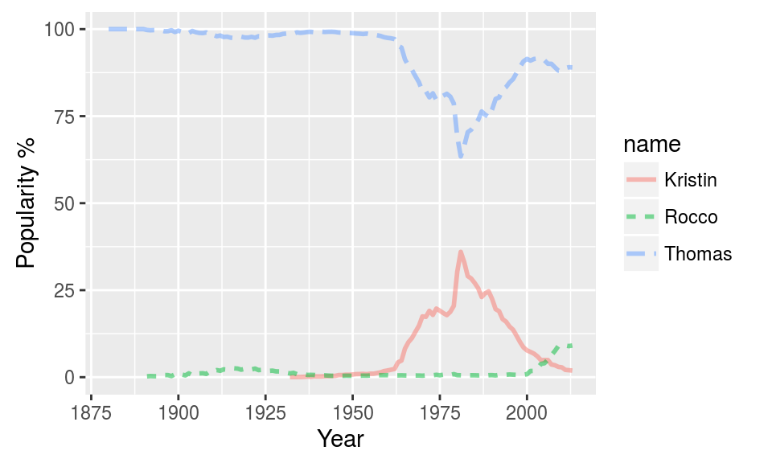

```r
BabyNames2 %>%
  ggplot(aes(x = year, y = Popularity, group = name)) +
  geom_line( size = 1, alpha = 0.5, aes(linetype = name, color = name)) +
  ylab("Popularity %") + xlab("Year")
```